# Flight Delay Factors

## Investigation Overview

In this investigation, I wanted to look at Which is the best time of the year to take a flight and what factors affecting arrival delays.

## Dataset Overview

The data consisted of flights approximately 14 million recorded flight information around europe and america in 2004 and 2008. the dataset includes Flight distances, number of flights, department delays/times, arrival delays/times, Weather Delays and also name of carriers which will play a part on my investigation.

## Distribution of Flight Distances(Overview of the dataset)

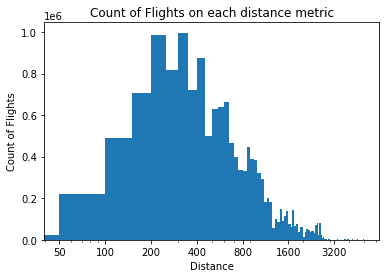

## Distribution of Flights per month

i'll be using a log transformation to give you a clear look on how different it is from a season to another the number of flights are. The graph shows that Summer and winter are mostly crowded while months February, September and November are the least crowded months with flights. also we can notice that in 2008 November flights are much lower than 2004 in the other side in Feb. number of flights in 2004 is lower than the ones in 2008 but in the overall graph you can see that the months i've mentioned are the best to take a flight on.

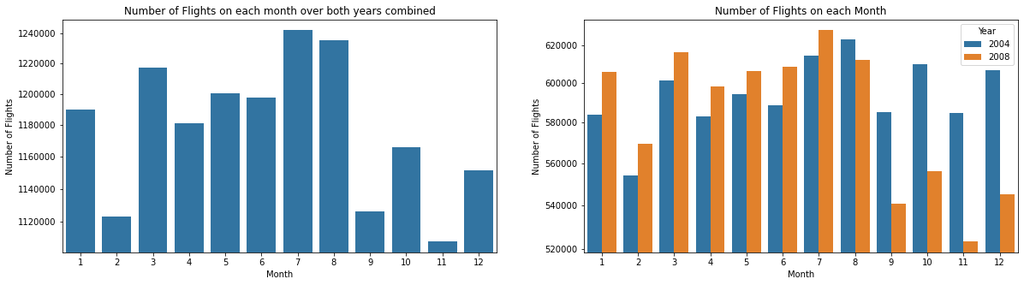

## Day of Week Vs Number of flights

I assume crowd is a main factor on a customer's happyness less crowd more happy. so we'll be lookin on which day of the week have the least number of flights, so a customer can go for a safe flight on saturdays!Since saturday is the day with the fewest number of flights you'd be lucky to book a flight on saturday.

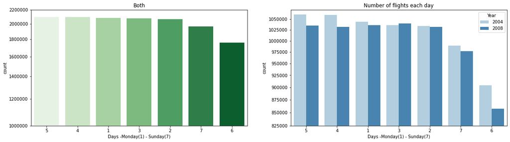

## Now Observe weather delay effects on flight arrival delays and which months have the worst weather delay to pick the optimal season to go out for vacation

There is an interaction effect visible between Weather Delay, Arrival Delay and the categorical Months. This is more precise for the best month to travel on rather than just the crowd, knowing seasons and weather delays on each month is also important in choosing a specific month. you'll notice that 2008 has way more delays caused by weather than 2004 but overall you can also notice that during summer and winter it's mostly high delay seasons. so the best time of the year would be spring and fall since they've the best weather of the year which affects planes the least.

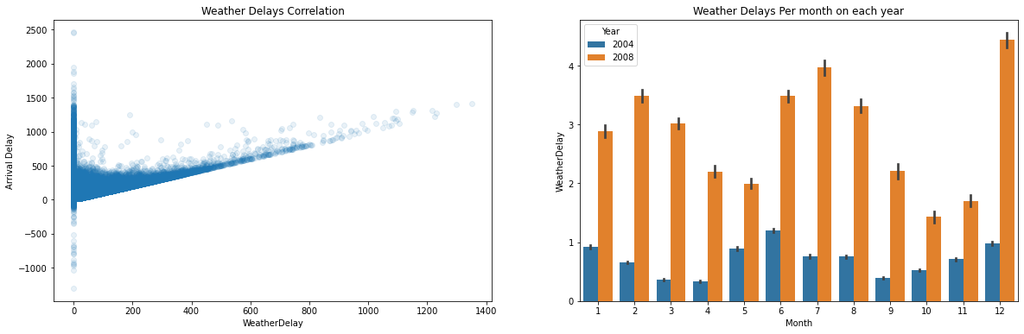

## Delays Vs Number of flights per Carrier.

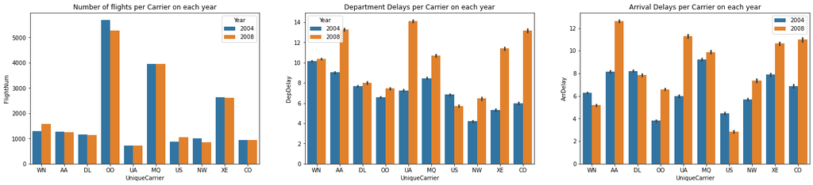